# Food Preferences from around the world

I would consider myself somewhat of a foodie, nothing gets me in a good mood like a good meal, me personally I’m a fan of more traditional food. Now this got me thinking, about how each country has their own type of food. I wonder do they share the same preferences as me?

Using a Kaggle data-set let’s find the answer.

For clarity sake in this project food that falls under the western food category will be fast food (i.e. McDonald’s, KFC, Burger King, etc.).

# Importing libraries

```r
library(tidyverse)
library(corrgram)
library(fastDummies)
library(ggthemes)
library(GGally)
```

# Getting our data

For this data viz project I will be taking a look at a Kaggle data set call [Food Preferences](https://www.kaggle.com/vijayashreer/food-preferences). The data was collected via survey that was conducted among participants from different countries and demographics.

```r
data <- read_csv('Food_Preference.csv')
head(data)
```

| Timestamp | Participant_ID | Gender | Nationality | Age | Food | Juice | Dessert |
| --- | --- | --- | --- | --- | --- | --- | --- |
| 2019/05/07 2:59:13 PM GMT+8 | FPS001 | Male | Indian | 24 | Traditional food | Fresh Juice | Maybe |
| 2019/05/07 2:59:45 PM GMT+8 | FPS002 | Female | Indian | 22 | Western Food | Carbonated drinks | Yes |
| 2019/05/07 3:00:05 PM GMT+8 | FPS003 | Male | Indian | 31 | Western Food | Fresh Juice | Maybe |
| 2019/05/07 3:00:11 PM GMT+8 | FPS004 | Female | Indian | 25 | Traditional food | Fresh Juice | Maybe |
| 2019/05/07 3:02:50 PM GMT+8 | FPS005 | Male | Indian | 27 | Traditional food | Fresh Juice | Maybe |
| 2019/05/07 3:03:34 PM GMT+8 | FPS006 | Male | Indian | 24 | Traditional food | Fresh Juice | Yes |

```r
summary(data)
```

```
  Timestamp         Participant_ID        Gender          Nationality
 Length:288         Length:288         Length:288         Length:288
 Class :character   Class :character   Class :character   Class :character
 Mode  :character   Mode  :character   Mode  :character   Mode  :character



      Age            Food              Juice             Dessert
 Min.   : 8.00   Length:288         Length:288         Length:288
 1st Qu.:24.00   Class :character   Class :character   Class :character
 Median :28.00   Mode  :character   Mode  :character   Mode  :character
 Mean   :30.60
 3rd Qu.:36.25
 Max.   :80.00
```

# Cleaning our data

Looking at our data we seem only to have missing values in regards to gender.

```
[1] "Male"   "Female" NA
```

This could be due to not in fact wanting to disclose their gender so we can change the “NA” to “Not disclosed” without any issues.

```
[1] "Male"          "Female"        "Not disclosed"
```

Another detail to take into account seems to be Nationality. There are multiple instances of the same nationality just in different forms. As well as a mystery nationality called “**MY**” that doesn’t seem to be an abbreviation of any known nation (For the purposes of this project it will count as Malaysian).

```
 [1] "Indian"      "Pakistani"   "Tanzanian"   "Indonesia"   "Muslim"
 [6] "Pakistan"    "Maldivian"   "MY"          "Malaysian"   "Indonesian"
[11] "MALAYSIAN"   "Malaysia"    "Canadian"    "Nigerian"    "Algerian"
[16] "Korean"      "Seychellois" "Indonesain"  "Japan"       "China"
[21] "Mauritian"   "Yemen"
```

```
 [1] "Indian"      "Pakistani"   "Tanzanian"   "Indonesian"  "Muslim"
 [6] "Maldivian"   "Malaysian"   "Canadian"    "Nigerian"    "Algerian"
[11] "Korean"      "Seychellois" "Indonesain"  "Japan"       "China"
[16] "Mauritian"   "Yemen"
```

# Data Analysis

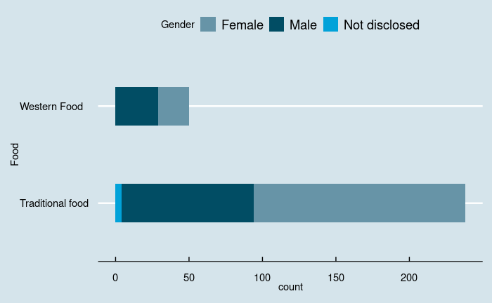

Why is this? According to an article publish by the [National Center for Biotechnology Information](https://www.ncbi.nlm.nih.gov/pmc/articles/PMC2531152/): “A growing body of evidence suggests that the food choices a mother makes during her pregnancy may set the stage for an infant’s later acceptance of solid foods.”

Due to women preferring more traditional food, a very likely scenario is that during pregnancy they would be more likely to consume traditional food which would be a contributing factor that leads into the offspring preferring traditional food.

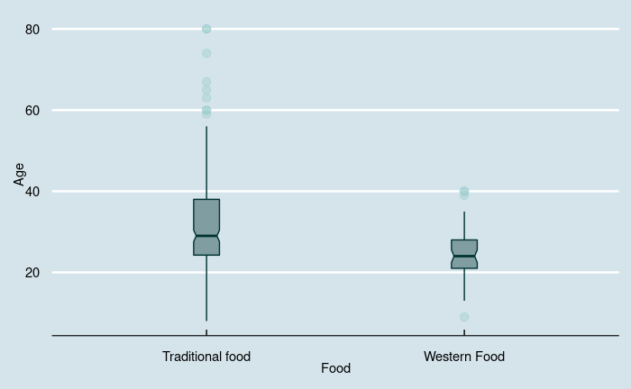

The older one seems to get, the more they prefer traditional food. In general though overall traditional food is enjoyed by all ages, whereas Western Food is enjoyed mostly by young adults.

This makes sense according to a study done by [Centers for Disease Control](https://www.cdc.gov/nchs/products/databriefs/db322.htm) which concluded that “the percentage of adults who consumed fast food decreased with age” with the highest consumption being done by people ages 20-39.

```
data in column(s) 'Food', 'Juice', 'Dessert' are not numeric and were ignored
```

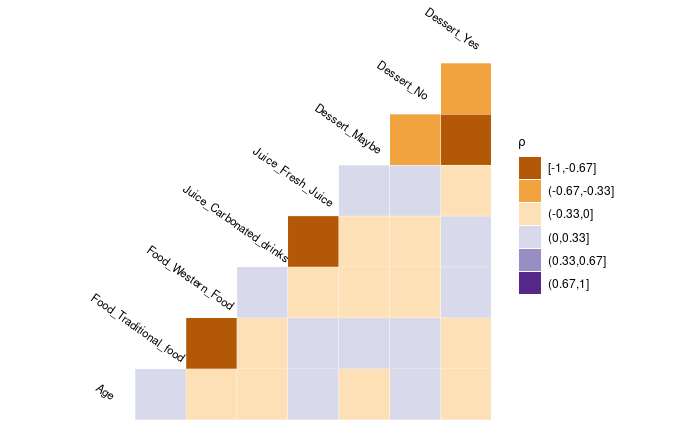

As you can see a lot of what we find correlated makes sense, for starters as we determined before we see a correlation between the age of someone and their preference for traditional food.

We can also infer that people who eat western food tend to have less than ideal diets, opting to drink carbonated drinks as well as eating dessert afterwards. While the inverse can be said for people who enjoy traditional food.

# Conclusion

We started off inferring based on my personal experience that people would prefer to eat more traditional food. After conducting my analysis I can say for certain that people from all age groups mostly women do in fact prefer traditional food.

People who eat western food also seem to lead a more unhealthy life style as they opt to drink carbonated drinks and eat dessert afterwards. However as people age the preference for western food decreases.